# Homework 1

### Due: Friday 9/19 at 10pm

This assignment has a total of 22 pts possible. Your score out of 20 will noted and scaled to 5 points (maximum of 5).

**Question 1 – Conceptual Questions:** (1pt each)

- **Part A** What does it mean to say two variables are *associated* with each other?
- **Part B** What does it mean to say two variables are *independent* of each other?
- **Part C** What does the distribution of a variable tell us?

**Question 2** For this question, we will be using the `iris` dataset, giving the measurements, in centimeters, of the variables for sepal and petal length and width. You can read more on the dataset [here](https://en.wikipedia.org/wiki/Iris_flower_data_set). An image of what these variables correspond to on a flower are provided below.

**NOTE:** You will need to edit out the image from your document in order for it to knit to a .pdf doc. If your doc does not knit, this may be the cause.

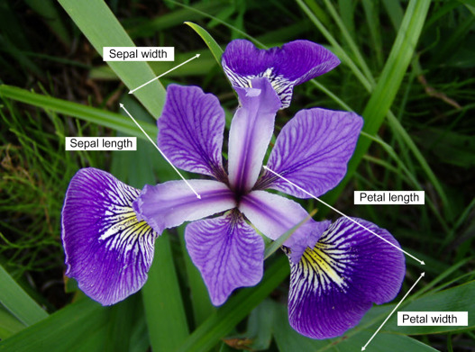

To load this data into R, simply copy and paste the following into your Rmd file in an R code chunk

```r
library(ggplot2)
data(iris)
```

Use this data to answer the following questions:

- **Part A** How many observations and variables are in the `iris` dataset? In one sentence, briefly describe what constitutes an observation in this data. (2 pts)
- **Part B** Use the code below to create the appropriate plot to visualize the relationship between the variables `Sepal.Width` and `Sepal.Length`. Do these two variables appear to be *associated*? If so, comment on the strength of this association. (2 pt)

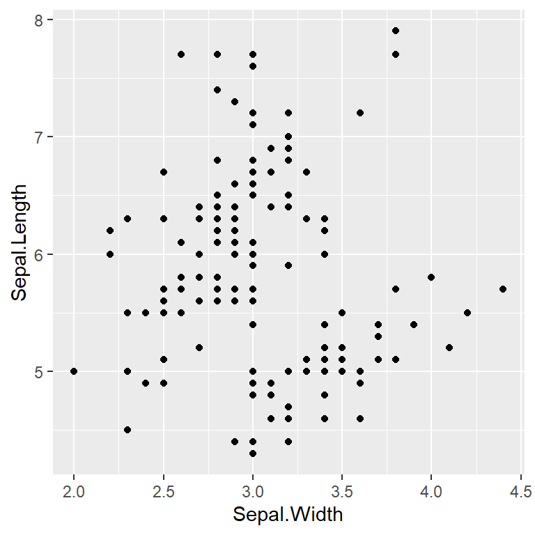

```r
ggplot(iris, aes(Sepal.Width, Sepal.Length)) + geom_point()
```

- **Part C** Use the code below to create the plot again, this time adding additional information for the variable `Species`. Has anything changed in the association between `Sepal.Width` and `Sepal.Length`? Comment on the **strength**, **form**, and **direction** of any associations you see (1pt)

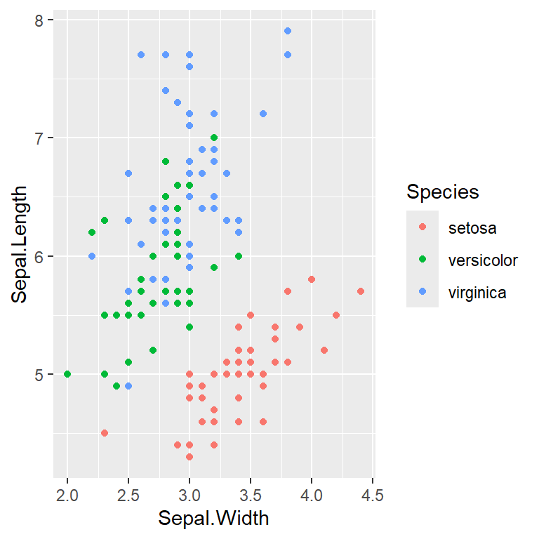

```r
ggplot(iris, aes(Sepal.Width, Sepal.Length, color = Species)) + geom_point()
```

**Question 3:**

From the [IMS Textbook](https://openintro-ims.netlify.app/), do the following exercises (you do not need to read anything from the textbook to answer these):

- Chapter 4.8: Questions 1, 3, 4, 5, 6
- Ch 5.10: Questions 11, 13

Write your answers to these exercises below.

I recommend developing a nice formatting for your questions like the following:

## IMS Chapter 4.8 – Question #1

**Part A**: What features are apparent in the bar plot but not in the pie chart?

*Answer:*

**Part B**: What features are apparent in the pie chart but not in the bar plot?

*Answer:*

**Part C**: Which graph would you prefer to use for displaying these categorical data?

*Answer:*